# Low-DHW mortality sensitivity and Lizard freshwater audit

## Question and test

The hypothesis is that non-thermal or compound-event losses observed below 4 DHW pull the beta response upward at low heat stress and flatten its increase at moderate-to-high DHW. This is a sensitivity analysis, not a data-cleaning rule.

Four versions of the same two-part Bayesian INLA model were fitted: mortality occurrence (Bernoulli) and positive mortality magnitude (beta). The model retained the established nonlinear DHW hinges at 4 and 8 DHW, Acropora composition, initial cover, repeated thermal exposure, water clarity and cloud terms. In every spatially blocked fold, suspect observations were removed **from training only**. All observations remained in held-out assessment, including the suspect rows.

This distinction matters: any improvement reported below must improve prediction of the original dataset, not a reduced and easier target.

## What is present below 4 DHW?

All observations with DHW < 4 and mortality >= 5%

| programme_key | ReefName | event_year | ann_maxdhw | mortality | observed_pre_cover | acropora | DISTURBANCE_TYPE | disturbance_has_cyclone | disturbance_has_flood | disturbance_has_cots |
| --- | --- | --- | --- | --- | --- | --- | --- | --- | --- | --- |
| manta | Mackay Reef (16-015) | 2024 | 3.52 | 61.3% | 0.43 | 11.1% | m | TRUE | TRUE | FALSE |
| manta | Swinger Reef (15-030) | 2024 | 3.87 | 34.6% | 0.41 | 56.9% | b | FALSE | FALSE | FALSE |
| ltmp | Mackay Reef (16-015) | 2024 | 3.52 | 25.5% | 0.24 | 11.1% | m | TRUE | TRUE | FALSE |
| ltmp | Rib Reef (18-032) | 2016 | 2.50 | 22.9% | 0.38 | 56.1% | m | FALSE | FALSE | TRUE |
| manta | Wansfell Reef (19-098) | 2024 | 3.37 | 19.9% | 0.32 | 18.8% | b | FALSE | FALSE | FALSE |
| manta | Broomfield Reef (23-048) | 2016 | 0.00 | 11.5% | 0.50 | 80.3% | NA | NA | NA | NA |
| manta | East Cay Reef (21-305) | 2017 | 1.79 | 11.2% | 0.32 | 19.1% | NA | NA | NA | NA |
| manta | Fairfax Islands Reef (23-081) | 2022 | 0.31 | 10.8% | 0.59 | 81.6% | m | FALSE | FALSE | TRUE |
| ltmp | East Cay Reef (21-305) | 2017 | 1.79 | 9.4% | 0.23 | 19.1% | NA | NA | NA | NA |

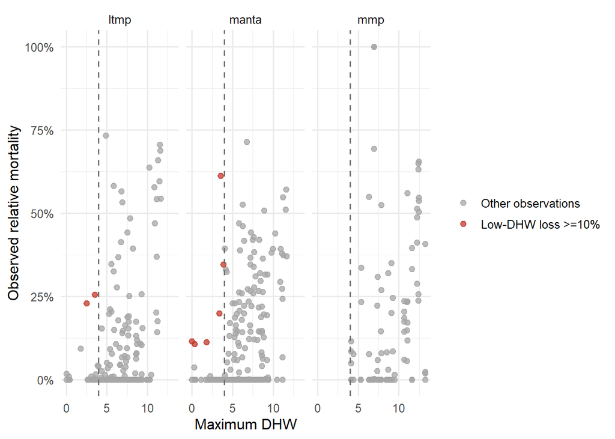

The reconstructed **ann_maxdhw** field contains no MMP observations below 4 DHW, so MMP was not altered by this exclusion test. A subsequent lineage audit found four retained 2024 Stingaree rows with legacy survey-linked DHW of 3.98 but reconstructed NOAA DHW of 4.15. The apparent absence is therefore field- and threshold-specific, not evidence that MMP rows were removed. It does not explain MMP severe-event underprediction.

The existing formal ensemble also does not show broad underprediction at low DHW. Averaged across the available held-out rows, it predicts more mortality than observed in both Manta and LTMP. A small number of high-loss observations are influential, but they sit within a low-DHW group dominated by zeros or small losses.

Existing formal-ensemble prediction below 4 DHW

| programme_key | n | observed | predicted | bias |
| --- | --- | --- | --- | --- |
| ltmp | 20 | 2.3% | 6.4% | 4.1% |
| manta | 38 | 4.1% | 6.0% | 1.9% |

## Does exclusion improve held-out prediction?

Spatially blocked performance on all assessment rows

| programme_key | variant_label | n | rmse | mae | predictive_r2 | bias_predicted_minus_observed |
| --- | --- | --- | --- | --- | --- | --- |
| ltmp | All training rows | 199 | 13.2% | 8.3% | 0.372 | 0.9% |
| ltmp | Exclude DHW < 4 and loss >= 5% | 199 | 13.2% | 8.1% | 0.379 | 0.7% |
| ltmp | Exclude DHW < 4 and loss >= 10% | 199 | 13.2% | 8.2% | 0.373 | 0.8% |
| ltmp | Exclude DHW < 4 and loss >= 20% | 199 | 13.2% | 8.2% | 0.373 | 0.8% |
| manta | All training rows | 248 | 11.8% | 8.4% | 0.412 | 0.1% |
| manta | Exclude DHW < 4 and loss >= 5% | 248 | 12.0% | 8.4% | 0.394 | -0.3% |
| manta | Exclude DHW < 4 and loss >= 10% | 248 | 12.0% | 8.4% | 0.394 | -0.3% |
| manta | Exclude DHW < 4 and loss >= 20% | 248 | 11.9% | 8.5% | 0.399 | -0.1% |

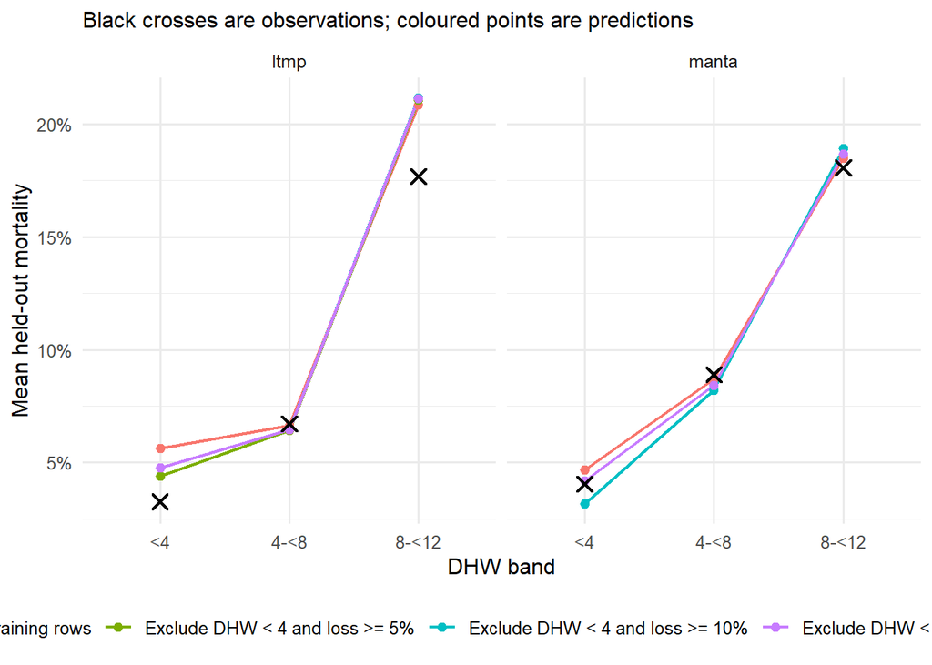

Baseline versus the primary 10% exclusion test

| programme_key | variant_label | dhw_band | n | observed_mean | predicted_mean | bias_predicted_minus_observed | rmse |
| --- | --- | --- | --- | --- | --- | --- | --- |
| ltmp | All training rows | <4 | 22 | 3.3% | 5.6% | 2.4% | 10.6% |
| ltmp | All training rows | 4-<8 | 131 | 6.7% | 6.7% | -0.1% | 12.8% |
| ltmp | All training rows | 8-<12 | 46 | 17.7% | 20.8% | 3.2% | 15.3% |
| ltmp | Exclude DHW < 4 and loss >= 10% | <4 | 22 | 3.3% | 4.8% | 1.5% | 9.9% |
| ltmp | Exclude DHW < 4 and loss >= 10% | 4-<8 | 131 | 6.7% | 6.5% | -0.3% | 12.8% |
| ltmp | Exclude DHW < 4 and loss >= 10% | 8-<12 | 46 | 17.7% | 21.2% | 3.5% | 15.6% |
| manta | All training rows | <4 | 38 | 4.1% | 4.7% | 0.6% | 9.4% |
| manta | All training rows | 4-<8 | 152 | 8.9% | 8.7% | -0.2% | 12.1% |
| manta | All training rows | 8-<12 | 58 | 18.1% | 18.5% | 0.4% | 12.6% |
| manta | Exclude DHW < 4 and loss >= 10% | <4 | 38 | 4.1% | 3.2% | -0.9% | 10.0% |
| manta | Exclude DHW < 4 and loss >= 10% | 4-<8 | 152 | 8.9% | 8.2% | -0.7% | 12.1% |
| manta | Exclude DHW < 4 and loss >= 10% | 8-<12 | 58 | 18.1% | 18.9% | 0.9% | 12.8% |

Performance for observed mortality >=50%

| programme_key | variant_label | n | observed_mean | predicted_mean | bias_predicted_minus_observed | rmse |
| --- | --- | --- | --- | --- | --- | --- |
| ltmp | All training rows | 12 | 61.4% | 38.8% | -22.6% | 31.4% |
| ltmp | Exclude DHW < 4 and loss >= 5% | 12 | 61.4% | 39.0% | -22.3% | 31.5% |
| ltmp | Exclude DHW < 4 and loss >= 10% | 12 | 61.4% | 39.1% | -22.2% | 31.4% |
| ltmp | Exclude DHW < 4 and loss >= 20% | 12 | 61.4% | 39.2% | -22.2% | 31.3% |
| manta | All training rows | 7 | 57.0% | 27.4% | -29.7% | 34.0% |
| manta | Exclude DHW < 4 and loss >= 5% | 7 | 57.0% | 26.3% | -30.7% | 35.7% |
| manta | Exclude DHW < 4 and loss >= 10% | 7 | 57.0% | 26.3% | -30.7% | 35.7% |
| manta | Exclude DHW < 4 and loss >= 20% | 7 | 57.0% | 26.8% | -30.2% | 34.8% |

The comparison above is the decision criterion. Information criteria are not comparable across variants because they were fitted to different response rows. The appropriate question is whether training exclusions improve prediction of the common, untouched assessment set.

The primary 10% exclusion does steepen the **mean band response** modestly. From the <4 to the 8–<12 band, the predicted increase changes from 13.8 to 15.8 percentage points for Manta and from 15.2 to 16.4 points for LTMP. That mechanical part of the hypothesis is supported.

It does not translate into better extreme prediction. For Manta observations with mortality >=50%, mean prediction falls from 27.4% to 26.3% and RMSE worsens from 34.0 to 35.7 percentage points. LTMP mean prediction changes only from 38.8% to 39.1%, with essentially unchanged RMSE. Overall Manta RMSE also worsens from 11.8% to 12.0%; LTMP is unchanged at 13.2%. The modestly steeper marginal curve is therefore not the missing mechanism.

## Where do predictions move?

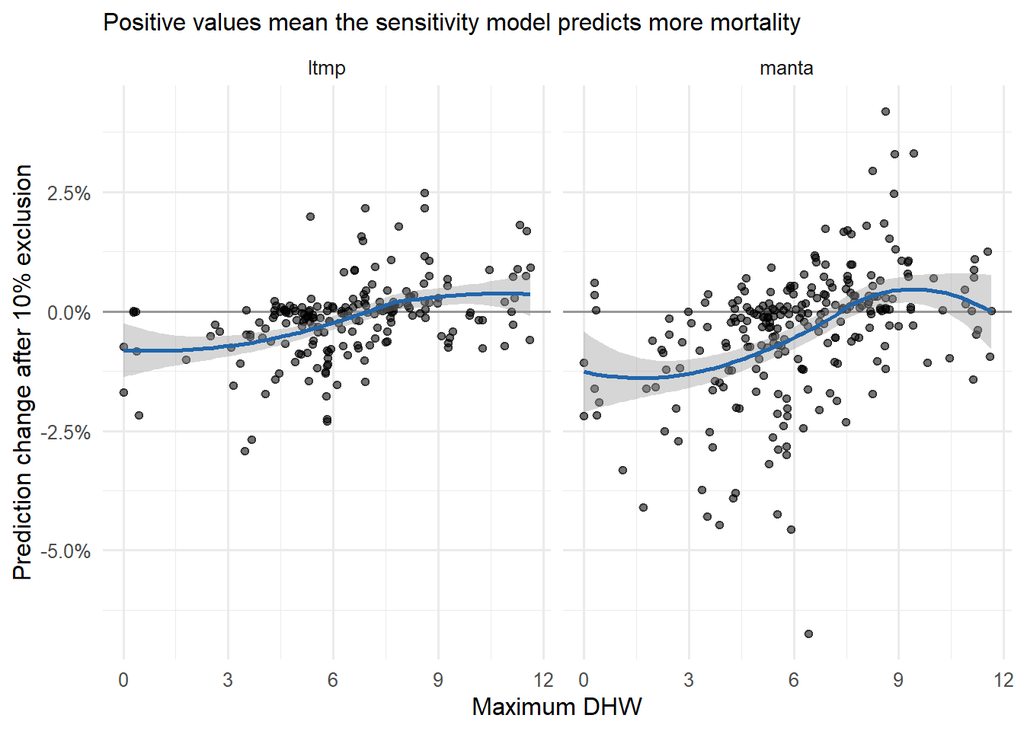

## Lizard Island cluster and freshwater evidence

The severe 2024 misses are spatially concentrated: Lizard North West, Eyrie and Linnet lie within about 18 km, with additional misses at nearby MacGillivray, Martin and South Direction. This makes a shared local or regional modifier plausible, but proximity alone does not identify the source.

Priority 2024 misses within 100 km of Lizard North West

| programme_key | ReefName | distance_to_lizard_nw_km | ann_maxdhw | observed | predicted | miss | era5_coastal_rain_max_30day | partial_ereefs_salinity_min |
| --- | --- | --- | --- | --- | --- | --- | --- | --- |
| manta | Linnet Reef (14-126) | 18.0 | 6.7 | 71.5% | 7.4% | 64.1% | 781.3 | 34.1 |
| manta | Eyrie Reef (14-118) | 9.3 | 6.3 | 52.6% | 5.1% | 47.5% | 781.3 | 34.0 |
| manta | Lizard Island Reef (North West) (14-116a) | 0.0 | 6.3 | 46.2% | 3.8% | 42.4% | 781.3 | 34.0 |
| ltmp | Linnet Reef (14-126) | 18.0 | 6.7 | 41.4% | 5.2% | 36.2% | 781.3 | 34.1 |
| manta | MacGillivray Reef (14-114) | 4.8 | 5.9 | 38.9% | 3.5% | 35.4% | 781.3 | 33.9 |
| ltmp | Martin Reef (14-123) | 15.2 | 6.4 | 36.8% | 4.6% | 32.2% | 781.3 | 34.1 |
| manta | Swinger Reef (15-030) | 65.6 | 3.9 | 34.6% | 6.6% | 28.0% | 841.5 | 33.1 |
| manta | South Direction Reef (North) (14-147a) | 20.2 | 6.4 | 22.3% | 3.4% | 18.9% | 781.3 | 33.9 |

There is **no continuous AIMS salinity logger in the Lizard region in the extracted dataset**. The nearest is RM8, about 285 km south, and the continuous record ends in October 2023. It cannot observe the 2024 Lizard event.

Nearest continuous AIMS logger sites

| site | site_latitude | site_longitude | distance_to_lizard_nw_km | first_time | last_time | salinity_hours |
| --- | --- | --- | --- | --- | --- | --- |
| RM8 | -17.2 | 146.0 | 284.8 | 2015-02-17 17:00:00 | 2023-10-25 11:00:00 | 71355 |
| RM10 | -17.2 | 146.0 | 288.6 | 2015-02-18 07:00:00 | 2023-10-25 10:00:00 | 75811 |
| TUL3 | -17.9 | 146.1 | 370.9 | 2015-02-21 15:00:00 | 2023-10-23 14:00:00 | 72527 |
| TUL10 | -18.0 | 146.1 | 380.0 | 2015-06-24 11:00:00 | 2023-10-23 09:00:00 | 70201 |

There are, however, discrete AIMS water-quality samples close to the affected reefs. They show appreciable freshening during the wet season: Lizard Island north declined from about 35.3 PSU in November to 33.8 PSU in February, and MacGillivray from about 35.2 to 34.1 PSU. Chlorophyll rose at both repeated sites. Eyrie was 34.26 PSU on 22 January and Linnet 33.28 PSU on 23 January.

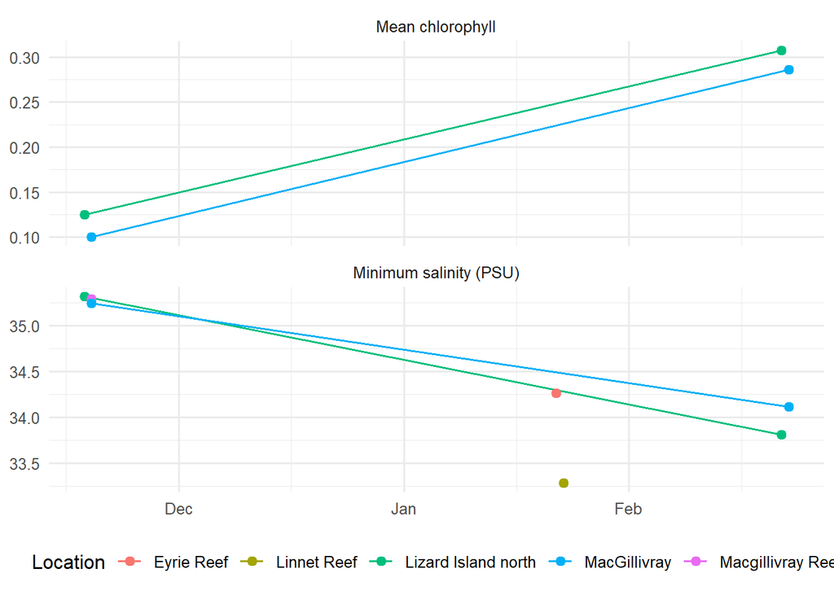

Repeated-site wet-season contrasts

| LOCATION_NAME | first_date | last_date | first_salinity | last_salinity | salinity_change_psu | first_chlorophyll | last_chlorophyll | chlorophyll_ratio |
| --- | --- | --- | --- | --- | --- | --- | --- | --- |
| Lizard Island north | 2023-11-18 | 2024-02-22 | 35.31 | 33.81 | -1.51 | 0.12 | 0.31 | 2.46 |
| MacGillivray | 2023-11-19 | 2024-02-23 | 35.24 | 34.11 | -1.13 | 0.10 | 0.29 | 2.85 |

These samples support a moderate freshwater/water-quality anomaly, but none measured salinity below 30 PSU. Because each date is effectively a snapshot, they could easily miss a shorter, stronger pulse. The spatial extent across offshore reefs also argues against assuming runoff from Lizard Island itself: cyclone rainfall, shelf-scale plume transport, or both are at least as plausible. The evidence supports a **compound freshwater modifier**, not yet a specific causal pathway.

## Modelling implication

Low-DHW/high-loss rows should not be silently removed from the production data. They include ecologically real compound events such as Mackay 2024. The defensible next step is to retain them and model the process that makes them unusual: rainfall/runoff or observed salinity, coloured water/chlorophyll, cyclone exposure, and interactions with DHW and community composition. A robust/heavy-tailed observation layer or explicit contamination component can limit leverage from genuinely unexplained non-thermal losses without pretending those events did not occur.